# RepResearchProj2

Taylor Van Anne

January 18, 2016

### About this document

This document is about analyzing events to determine which are the most dangerous in terms of human health (fatalities and injuries) as well as which are the most economically destructive (cause the highest property damage).  
Events with highest average annual count of injuries – Tornado, Flood, Excessive Heat, Lightning, Hurricane (Typhoon)  
Events with highest average annual count of fatalities – Excessive Heat, Tornado, Heat, Flash Flood, Lightning  
Events with highest average annual amount of property damage caused – Hurricane (Typhoon), Flood, Storm Surge/Tide, Flash Flood, Tornado

## Data Processing

If an event type was captured for a certain year, I assume that that particular event type was captured for the entire year. Since not all event types were captured for all years, my strategy was to 1) group the data into event/year pairs and find the sum of the fatalities and injuries for those pairs. 2) group that data by event only, then take the average of the sums for fatalities and injuries (which collapses the yearly data).

These are the libraries used for the below processing.

```r
    library(dplyr)
```

```r
    library(ggplot2)
    library(reshape)
    library(lubridate)
    library(stringdist)
```

1. Load the dataset:

```r
rawdata <- read.csv("../data/repdata-data-StormData.csv.bz2", stringsAsFactors=FALSE)
```

2. Create date values using the lubridate package. Also, split one into year.

```r
#Make some real date fields, then take a sample of data
    rawdata$DATE <- parse_date_time(rawdata$BGN_DATE, orders = "mdy hms")
    rawdata$YEAR <- year(rawdata$DATE)
```

3. Clean the EVTYPE field. There are 47 real event types that these should all fall into.

```r
#clean EVTYPE
    clean_EVTYPEs <- read.csv("clean_EVTYPEs.csv", stringsAsFactors = FALSE)
    clean_EVTYPEs <- toupper(clean_EVTYPEs$Clean_EVTYPEs)
    dirty_EVTYPEs <- rawdata$EVTYPE
    EVTYPE_Indeces <- amatch(dirty_EVTYPEs, clean_EVTYPEs, maxDist=23)
    clean_Events <- clean_EVTYPEs[EVTYPE_Indeces]
    rawdata$Clean_Event <- clean_Events
    rawdata_clean_nas <- filter(rawdata, is.na(Clean_Event))
    testrawdata <- as.data.frame(rawdata$EVTYPE); testrawdata$clean <- rawdata$Clean_Event
```

4. Group the data by the newly created Event type field as well as Year.

```r
    rawdata$EVTYPE <- as.factor(rawdata$EVTYPE)

    #group by event type and year
    rawdata.evt.grp <- group_by(rawdata, Clean_Event, YEAR)  #this can be used for both Q1 and Q2
    rawdata.evt.summ <- summarize(rawdata.evt.grp, 'sum_fatalities'=sum(FATALITIES, na.rm = TRUE),
                                   'sum_injuries'=sum(INJURIES, na.rm = TRUE))
```

5. Take the resulting data set, turn it into a data frame, then group by only the event type. Finally, take the average of the fatalities and injuries per year. This will collapse the year field.

```r
    rawdata.evt.summ <- as.data.frame(rawdata.evt.summ)
    #now group ONLY by event type
    rawdata.evt.summ.grp <- group_by(rawdata.evt.summ, Clean_Event)

    #this will collapse the sums for each year into averages across all years
    rawdata.avg <- summarize(rawdata.evt.summ.grp, 'avg_fatalities'=mean(sum_fatalities),
                             'avg_injuries'=mean(sum_injuries))
```

6. Filter the resulting dataset to records with more than 10 fatalities and then arrange in order of most to least average annual fatalities.

```r
    #highest fatalities
    rawdata.avg.flt <- filter(rawdata.avg, avg_fatalities > 10)
    topFatalities <- arrange(rawdata.avg.flt, desc(avg_fatalities))
    topFatalities
```

```
## Source: local data frame [12 x 3]
##
##            Clean_Event avg_fatalities avg_injuries
##                  (chr)          (dbl)        (dbl)
## 1       EXCESSIVE HEAT      112.22222    372.38889
## 2              TORNADO       90.85484   1473.61290
## 3                 HEAT       70.00000    154.06250
## 4          FLASH FLOOD       55.00000     95.10526
## 5            LIGHTNING       43.05263    275.42105
## 6                FLOOD       32.15789    416.47368
## 7          RIP CURRENT       32.05556     29.38889
## 8    THUNDERSTORM WIND       14.18750    154.18750
## 9            HIGH WIND       14.15789    149.92982
## 10           AVALANCHE       12.10526     10.21053
## 11 HURRICANE (TYPHOON)       12.00000    213.16667
## 12        WINTER STORM       11.47368     74.47368
```

```r
    top5FatalEvt <- topFatalities[1:5, ]
    colnames(top5FatalEvt) <- c("Event_Type", "Avg_Fatalities_per_Year", "Avg_Injuries_per_Year")
```

7. Conduct the same steps but for highest injuries.

```r
    #highest injuries
    rawdata.avg.flt2 <- filter(rawdata.avg, avg_injuries > 10)
    topInjuries <- arrange(rawdata.avg.flt2, desc(avg_injuries))
    topInjuries
```

```
## Source: local data frame [27 x 3]
##
##            Clean_Event avg_fatalities avg_injuries
##                  (chr)          (dbl)        (dbl)
## 1              TORNADO      90.854839   1473.61290
## 2                FLOOD      32.157895    416.47368
## 3       EXCESSIVE HEAT     112.222222    372.38889
## 4            LIGHTNING      43.052632    275.42105
## 5  HURRICANE (TYPHOON)      12.000000    213.16667
## 6    THUNDERSTORM WIND      14.187500    154.18750
## 7                 HEAT      70.000000    154.06250
## 8            HIGH WIND      14.157895    149.92982
## 9            ICE STORM       5.052632    106.42105
## 10         FLASH FLOOD      55.000000     95.10526
## ..                 ...            ...          ...
```

```r
    top5InjuryEvt <- topInjuries[1:5, ]
    top5InjuryEvt
```

```
## Source: local data frame [5 x 3]
##
##           Clean_Event avg_fatalities avg_injuries
##                 (chr)          (dbl)        (dbl)
## 1             TORNADO       90.85484    1473.6129
## 2               FLOOD       32.15789     416.4737
## 3      EXCESSIVE HEAT      112.22222     372.3889
## 4           LIGHTNING       43.05263     275.4211
## 5 HURRICANE (TYPHOON)       12.00000     213.1667
```

```r
    colnames(top5InjuryEvt) <- c("Event_Type", "Avg_Fatalities_per_Year", "Avg_Injuries_per_Year")
```

8. Filter for records that only have a clean value in the PROPDMGEXP field (Thousands, Millions, Billions).

```r
    #We only care about these fields really
    rawdata$PROPDMGEXP <- toupper(rawdata$PROPDMGEXP)
    rawdata.flt <- filter(rawdata, PROPDMGEXP == "K" | PROPDMGEXP == "B" | PROPDMGEXP == "M")
```

9. Multiply the property damage value by the multiplier K, M, or B (Thousands, Millions, Billions).

```r
     rawdata.flt$PropertyDamage <- 0
    for (i in 1:nrow(rawdata.flt)) {
        if (rawdata.flt$PROPDMGEXP[i] == "K") {
            rawdata.flt$PropertyDamage[i] <- rawdata.flt$PROPDMG[i] * 1000
        } else if (rawdata.flt$PROPDMGEXP[i] == "M") {
            rawdata.flt$PropertyDamage[i] <- rawdata.flt$PROPDMG[i] * 1000000
        } else if (rawdata.flt$PROPDMGEXP[i] == "B") {
            rawdata.flt$PropertyDamage[i] <- rawdata.flt$PROPDMG[i] * 1000000000
        }
    }
```

10. Group raw dataset by Event Type and Year (again) and sum the property damage:

```r
    rawdata.flt.grpby <- group_by(rawdata.flt, Clean_Event, YEAR)
    rawdata.flt.summ <- summarize(rawdata.flt.grpby, 'sum_propertydmg'=sum(PropertyDamage))
```

11. Convert the resulting dataset

```r
    rawdata.flt.summ <- as.data.frame(rawdata.flt.summ)
    rawdata.flt.grpby2 <- group_by(rawdata.flt.summ, Clean_Event)
    rawdata.flt.summ2 <- summarize(rawdata.flt.grpby2, 'avg_propertydmg'=mean(sum_propertydmg))
    rawdata.flt.summ2.arrg <- arrange(rawdata.flt.summ2, desc(avg_propertydmg))

    top5PropertyDmg <- rawdata.flt.summ2.arrg[1:5, ]
    top5PropertyDmg <- as.data.frame(top5PropertyDmg)
```

12. Create real currency-looking values based on the total average property damage per year value from the previously created dataset.

```r
   for (i in 1:nrow(top5PropertyDmg)) {
        top5PropertyDmg$Dollar[i] <- paste("$",format(top5PropertyDmg[i,2], big.mark=","),sep="")
    }
```

## Results

Results for highest Injuries:

```r
    top5InjuryEvt
```

```
## Source: local data frame [5 x 3]
##
##            Event_Type Avg_Fatalities_per_Year Avg_Injuries_per_Year
##                 (chr)                   (dbl)                 (dbl)
## 1             TORNADO                90.85484             1473.6129
## 2               FLOOD                32.15789              416.4737
## 3      EXCESSIVE HEAT               112.22222              372.3889
## 4           LIGHTNING                43.05263              275.4211
## 5 HURRICANE (TYPHOON)                12.00000              213.1667
```

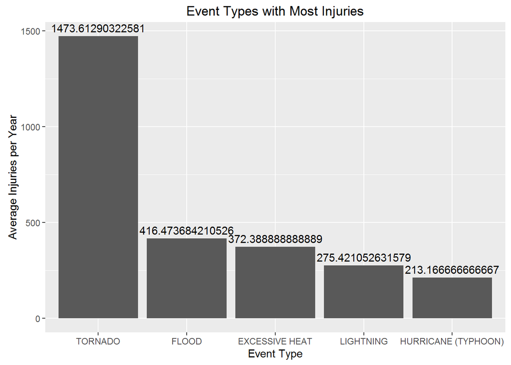

```r
    ggplot(top5InjuryEvt, aes(x = reorder(Event_Type, -Avg_Injuries_per_Year), y = Avg_Injuries_per_Year)) +
        geom_bar(stat = "identity") +
        xlab("Event Type") +
        ylab("Average Injuries per Year") +
        ggtitle("Event Types with Most Injuries") +
        geom_text(aes(label = Avg_Injuries_per_Year), vjust = -0.5)
```

Tornados cause the most injuries on average per year.

Results for highest Fatalities:

```r
    top5FatalEvt
```

```
## Source: local data frame [5 x 3]
##
##       Event_Type Avg_Fatalities_per_Year Avg_Injuries_per_Year
##            (chr)                   (dbl)                 (dbl)
## 1 EXCESSIVE HEAT               112.22222             372.38889
## 2        TORNADO                90.85484            1473.61290
## 3           HEAT                70.00000             154.06250
## 4    FLASH FLOOD                55.00000              95.10526
## 5      LIGHTNING                43.05263             275.42105
```

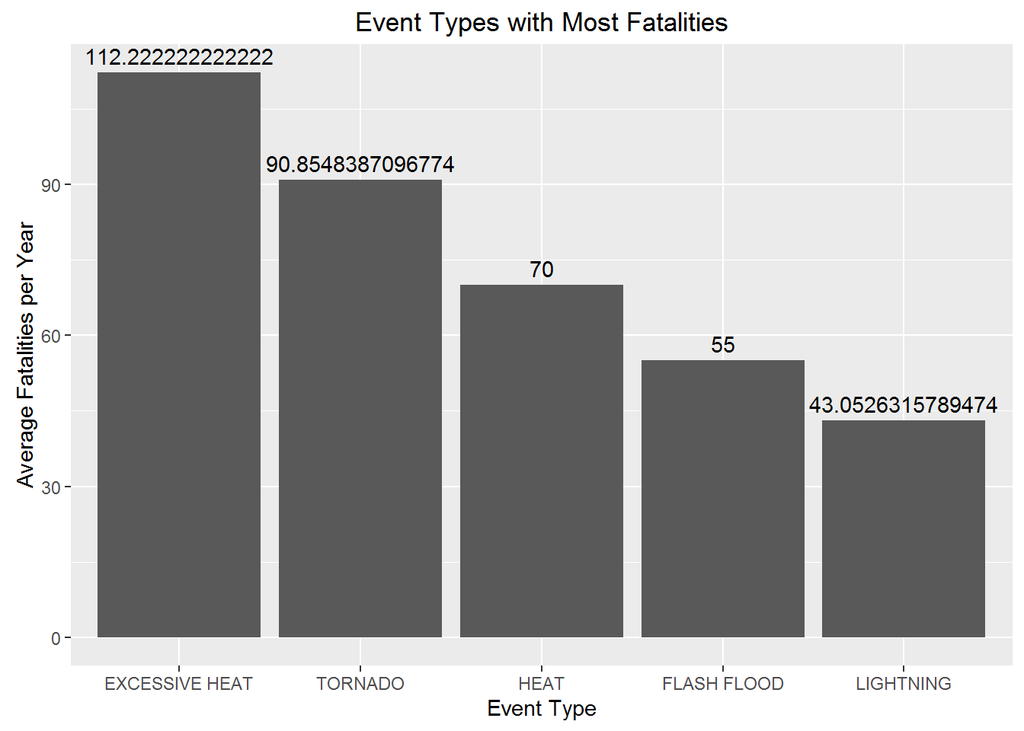

```r
    ggplot(top5FatalEvt, aes(x = reorder(Event_Type, -Avg_Fatalities_per_Year),
                             y = Avg_Fatalities_per_Year)) +
        geom_bar(stat = "identity") +
        xlab("Event Type") +
        ylab("Average Fatalities per Year") +
        ggtitle("Event Types with Most Fatalities") +
        geom_text(aes(label = Avg_Fatalities_per_Year), vjust = -0.5)
```

Excessive heat causes the most fatalities on average per year.

Results for highest Property Damage:

```r
   top5PropertyDmg
```

```
##           Clean_Event avg_propertydmg          Dollar
## 1 HURRICANE (TYPHOON)     12122976833 $12,122,976,833
## 2               FLOOD      7656266755  $7,656,266,755
## 3    STORM SURGE/TIDE      2524472579  $2,524,472,579
## 4         FLASH FLOOD      1186307288  $1,186,307,288
## 5             TORNADO       918419908    $918,419,908
```

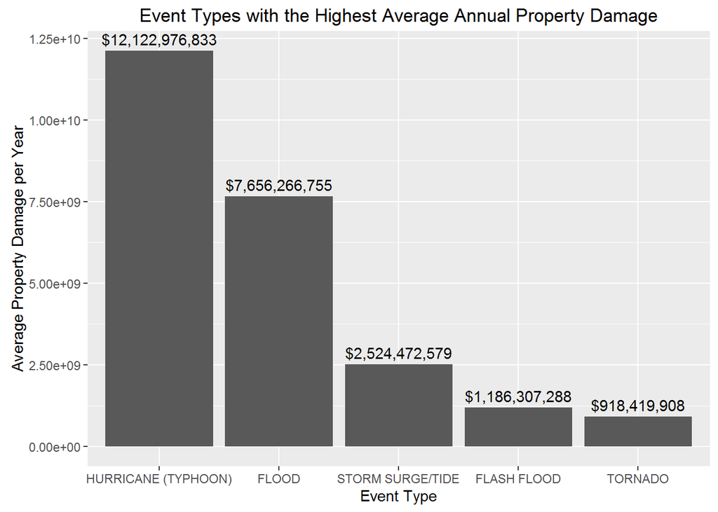

```r
    ggplot(top5PropertyDmg, aes(x = reorder(Clean_Event, -avg_propertydmg), y = avg_propertydmg)) +
        geom_bar(stat = "identity") +
        xlab("Event Type") +
        ylab("Average Property Damage per Year") +
        ggtitle("Event Types with the Highest Average Annual Property Damage") +
        geom_text(aes(label = Dollar), vjust = -0.5)
```

Hurricanes (Typhoons) cause the most property damage on average per year.